# LEARN SEABORN PYTHON LIBRARY

# pair plot method

```python
import seaborn as sns
import matplotlib.pyplot as plt
import pandas as pd
import numpy as np

pf=sns.load_dataset("tips").head(10)
pf
```

|  | total_bill | tip | sex | smoker | day | time | size |
| --- | --- | --- | --- | --- | --- | --- | --- |
| 0 | 16.99 | 1.01 | Female | No | Sun | Dinner | 2 |
| 1 | 10.34 | 1.66 | Male | No | Sun | Dinner | 3 |
| 2 | 21.01 | 3.50 | Male | No | Sun | Dinner | 3 |
| 3 | 23.68 | 3.31 | Male | No | Sun | Dinner | 2 |
| 4 | 24.59 | 3.61 | Female | No | Sun | Dinner | 4 |
| 5 | 25.29 | 4.71 | Male | No | Sun | Dinner | 4 |
| 6 | 8.77 | 2.00 | Male | No | Sun | Dinner | 2 |
| 7 | 26.88 | 3.12 | Male | No | Sun | Dinner | 4 |
| 8 | 15.04 | 1.96 | Male | No | Sun | Dinner | 2 |
| 9 | 14.78 | 3.23 | Male | No | Sun | Dinner | 2 |

[figure not shown]

```python
sns.pairplot(pf)
plt.show()
```

[figure not shown]

```python
sns.pairplot(pf,hue="sex")
plt.show()
```

[figure not shown]

```python
sns.pairplot(pf,vars=["total_bill","tip"],hue="sex",
             hue_order=["Female","Male"],palette="rocket")
plt.show()
```

[figure not shown]

```python
sns.pairplot(pf,hue="sex",hue_order=["Female","Male"],y_vars=["total_bill","tip"],palette="rocket")
plt.show()
```

**we can change the kind of plot in pair method like using kind parameter we have forms lke kde,scatter,hist,reg**

diag_kind parameter used to fix the plot not showiing using kind so t changes accordingly below kde to hist is shown

[figure not shown]

```python
sns.pairplot(pf,hue="sex",hue_order=["Female","Male"],kind="kde",diag_kind="hist")
plt.show()
```

[figure not shown]

```python
sns.pairplot(pf,hue="sex",hue_order=["Female","Male"],markers=["*","<"])
plt.show()
```

# STRIP PLOT METHOD

```python
import seaborn as sns
import matplotlib.pyplot as plt
import pandas as pd
import numpy as np

pf=sns.load_dataset("tips")
pf
```

|  | total_bill | tip | sex | smoker | day | time | size |
| --- | --- | --- | --- | --- | --- | --- | --- |
| 0 | 16.99 | 1.01 | Female | No | Sun | Dinner | 2 |
| 1 | 10.34 | 1.66 | Male | No | Sun | Dinner | 3 |
| 2 | 21.01 | 3.50 | Male | No | Sun | Dinner | 3 |
| 3 | 23.68 | 3.31 | Male | No | Sun | Dinner | 2 |
| 4 | 24.59 | 3.61 | Female | No | Sun | Dinner | 4 |
| ... | ... | ... | ... | ... | ... | ... | ... |
| 239 | 29.03 | 5.92 | Male | No | Sat | Dinner | 3 |
| 240 | 27.18 | 2.00 | Female | Yes | Sat | Dinner | 2 |
| 241 | 22.67 | 2.00 | Male | Yes | Sat | Dinner | 2 |
| 242 | 17.82 | 1.75 | Male | No | Sat | Dinner | 2 |
| 243 | 18.78 | 3.00 | Female | No | Thur | Dinner | 2 |

244 rows × 7 columns

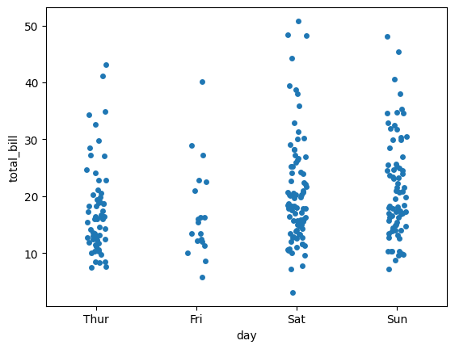

```python
sns.stripplot(x="day",y="total_bill",data=pf)
plt.show()
```

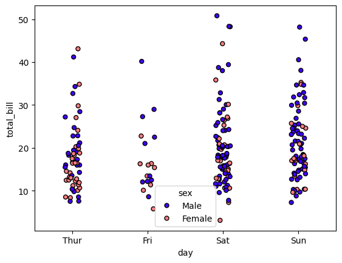

```python
sns.stripplot(x="day",y="total_bill",data=pf,hue="sex",
              palette="gnuplot2",linewidth=1,edgecolor="black")
plt.show()
```

**to make change in horizontal distace jitter parameter is used**

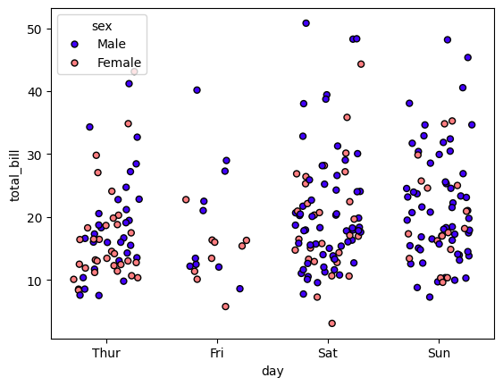

```python
sns.stripplot(x="day",y="total_bill",data=pf,hue="sex",
              palette="gnuplot2",linewidth=1,edgecolor="black",jitter=0.3)
plt.show()
```

size parameter, there are some more parameters like alpha , marker etc can be used

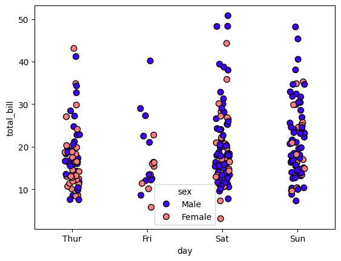

```python
sns.stripplot(x="day",y="total_bill",data=pf,hue="sex",
              palette="gnuplot2",linewidth=1,edgecolor="black",size=7)
plt.show()
```

if we want to plot a single stripplot we can also do it

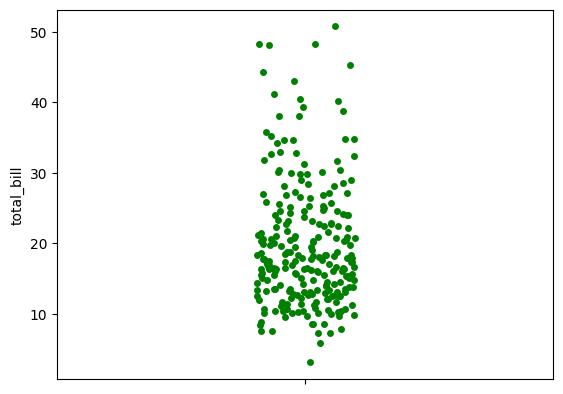

```python
sns.stripplot(y=pf["total_bill"],color="g")
plt.show()
```

# BOX PLOT METHOD

```python
import seaborn as sns
import matplotlib.pyplot as plt
import pandas as pd
import numpy as np

pf=sns.load_dataset("tips")
pf
```

|  | total_bill | tip | sex | smoker | day | time | size |
| --- | --- | --- | --- | --- | --- | --- | --- |
| 0 | 16.99 | 1.01 | Female | No | Sun | Dinner | 2 |
| 1 | 10.34 | 1.66 | Male | No | Sun | Dinner | 3 |
| 2 | 21.01 | 3.50 | Male | No | Sun | Dinner | 3 |
| 3 | 23.68 | 3.31 | Male | No | Sun | Dinner | 2 |
| 4 | 24.59 | 3.61 | Female | No | Sun | Dinner | 4 |
| ... | ... | ... | ... | ... | ... | ... | ... |
| 239 | 29.03 | 5.92 | Male | No | Sat | Dinner | 3 |
| 240 | 27.18 | 2.00 | Female | Yes | Sat | Dinner | 2 |
| 241 | 22.67 | 2.00 | Male | Yes | Sat | Dinner | 2 |
| 242 | 17.82 | 1.75 | Male | No | Sat | Dinner | 2 |
| 243 | 18.78 | 3.00 | Female | No | Thur | Dinner | 2 |

244 rows × 7 columns

[figure not shown]

```python
sns.set(style="whitegrid")

sns.boxplot(x="day",y="total_bill",data=pf)
plt.show()
```

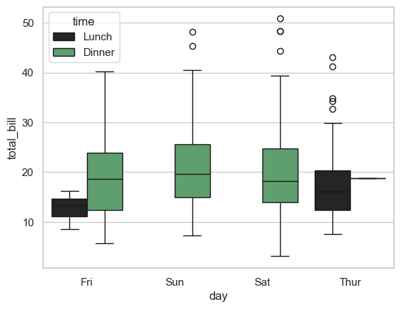

```python
sns.boxplot(x="day",y="total_bill",data=pf,hue="time",palette='dark:g',
            order=["Fri","Sun","Sat","Thur"])
plt.show()
```

to show mean in box plot

there are some more parameters like linewidth, orient (for orient both data should be numerical) etc

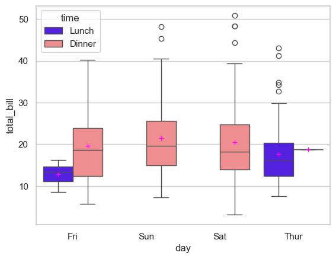

```python
sns.boxplot(x="day",y="total_bill",data=pf,hue="time",palette='gnuplot2',
            order=["Fri","Sun","Sat","Thur"],showmeans=True,
            meanprops={"marker":"+","markeredgecolor":"magenta"})
plt.show()
```

FOR SINGLE DATASET PLOT

[figure not shown]

```python
sns.set(style="white")

sns.boxplot(y=pf["total_bill"])
plt.show()
```

# CAT PLOT METHOD

factor plot is replaed with catplot and it worked to plot different plot at same time using catplot

```python
import seaborn as sns
import matplotlib.pyplot as plt
import pandas as pd
import numpy as np

pf=sns.load_dataset("tips").head(20)
pf
```

|  | total_bill | tip | sex | smoker | day | time | size |
| --- | --- | --- | --- | --- | --- | --- | --- |
| 0 | 16.99 | 1.01 | Female | No | Sun | Dinner | 2 |
| 1 | 10.34 | 1.66 | Male | No | Sun | Dinner | 3 |
| 2 | 21.01 | 3.50 | Male | No | Sun | Dinner | 3 |
| 3 | 23.68 | 3.31 | Male | No | Sun | Dinner | 2 |
| 4 | 24.59 | 3.61 | Female | No | Sun | Dinner | 4 |
| 5 | 25.29 | 4.71 | Male | No | Sun | Dinner | 4 |
| 6 | 8.77 | 2.00 | Male | No | Sun | Dinner | 2 |
| 7 | 26.88 | 3.12 | Male | No | Sun | Dinner | 4 |
| 8 | 15.04 | 1.96 | Male | No | Sun | Dinner | 2 |
| 9 | 14.78 | 3.23 | Male | No | Sun | Dinner | 2 |
| 10 | 10.27 | 1.71 | Male | No | Sun | Dinner | 2 |
| 11 | 35.26 | 5.00 | Female | No | Sun | Dinner | 4 |
| 12 | 15.42 | 1.57 | Male | No | Sun | Dinner | 2 |
| 13 | 18.43 | 3.00 | Male | No | Sun | Dinner | 4 |
| 14 | 14.83 | 3.02 | Female | No | Sun | Dinner | 2 |
| 15 | 21.58 | 3.92 | Male | No | Sun | Dinner | 2 |
| 16 | 10.33 | 1.67 | Female | No | Sun | Dinner | 3 |
| 17 | 16.29 | 3.71 | Male | No | Sun | Dinner | 3 |
| 18 | 16.97 | 3.50 | Female | No | Sun | Dinner | 3 |
| 19 | 20.65 | 3.35 | Male | No | Sat | Dinner | 3 |

by using kind parameter we potted a point plot

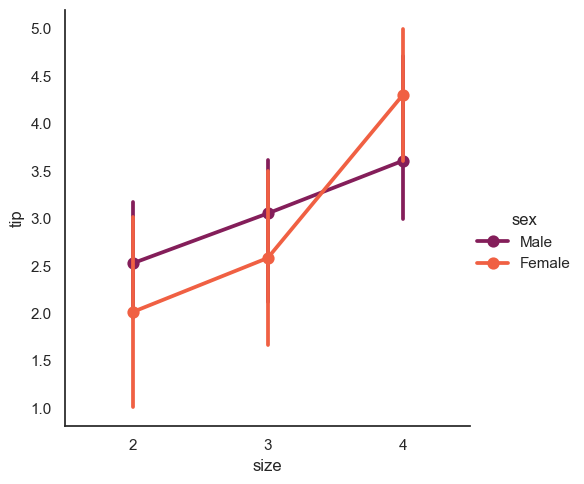

```python
sns.catplot(x="size",y="tip",data=pf,hue="sex",palette="rocket",
           kind="point")
plt.show()
```

# styling plot while plotting in seaborn

```python
import seaborn as sns
import matplotlib.pyplot as plt
import pandas as pd

pf=sns.load_dataset("tips")
pf
```

|  | total_bill | tip | sex | smoker | day | time | size |
| --- | --- | --- | --- | --- | --- | --- | --- |
| 0 | 16.99 | 1.01 | Female | No | Sun | Dinner | 2 |
| 1 | 10.34 | 1.66 | Male | No | Sun | Dinner | 3 |
| 2 | 21.01 | 3.50 | Male | No | Sun | Dinner | 3 |
| 3 | 23.68 | 3.31 | Male | No | Sun | Dinner | 2 |
| 4 | 24.59 | 3.61 | Female | No | Sun | Dinner | 4 |
| ... | ... | ... | ... | ... | ... | ... | ... |
| 239 | 29.03 | 5.92 | Male | No | Sat | Dinner | 3 |
| 240 | 27.18 | 2.00 | Female | Yes | Sat | Dinner | 2 |
| 241 | 22.67 | 2.00 | Male | Yes | Sat | Dinner | 2 |
| 242 | 17.82 | 1.75 | Male | No | Sat | Dinner | 2 |
| 243 | 18.78 | 3.00 | Female | No | Thur | Dinner | 2 |

244 rows × 7 columns

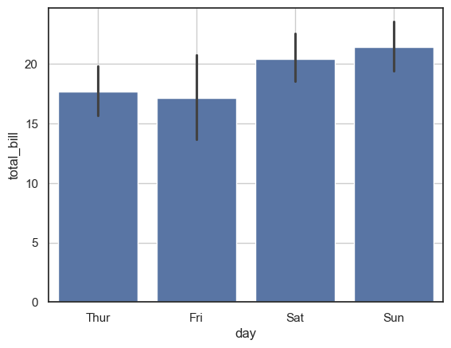

```python
sns.barplot(x="day",y="total_bill",data=pf)
plt.show()
```

making of grid using seaborn

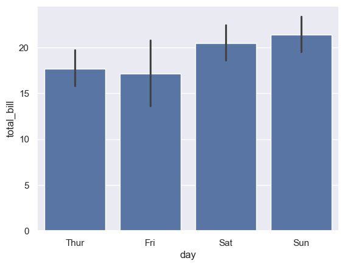

```python
sns.set_style("darkgrid")

sns.barplot(x="day",y="total_bill",data=pf)

plt.show()
```

to remove axis line we use despine parameter

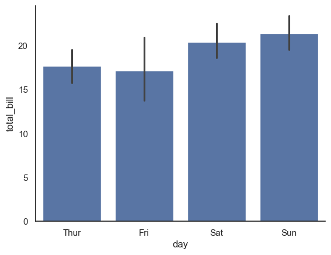

```python
sns.set_style("white")

sns.barplot(x="day",y="total_bill",data=pf)

sns.despine()
plt.show()
```

to increase figure size it is the funtion of matplotlib by using plt.figure()

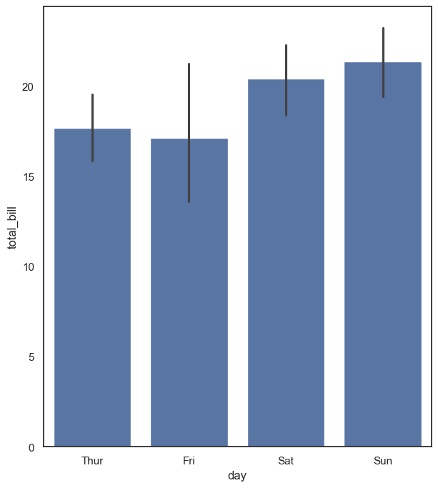

```python
sns.set_style("white")
plt.figure(figsize=(7,8))

sns.barplot(x="day",y="total_bill",data=pf)


plt.show()
```

change in content like fonts etc. by using sns.set_context() parameter in which there is many options like paper,poster,talk etc

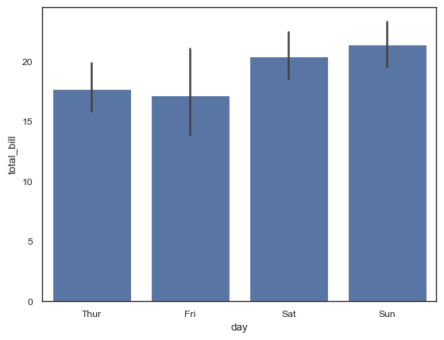

```python
sns.set_style("white")

sns.set_context("paper",font_scale=1)

sns.barplot(x="day",y="total_bill",data=pf)


plt.show()
```

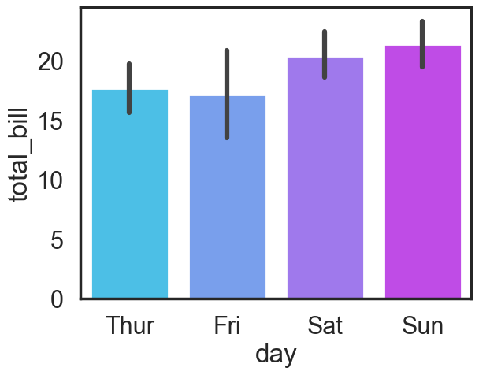

```python
sns.set_style("white")

sns.set_context("poster",font_scale=1)

sns.barplot(x="day",y="total_bill",data=pf,palette="cool")


plt.show()
```

# MULTIPLE PLOTS (FACET-GRID) IN SEABORN

```python
import seaborn as sns
import matplotlib.pyplot as plt

pf=sns.load_dataset("tips")
pf
```

|  | total_bill | tip | sex | smoker | day | time | size |
| --- | --- | --- | --- | --- | --- | --- | --- |
| 0 | 16.99 | 1.01 | Female | No | Sun | Dinner | 2 |
| 1 | 10.34 | 1.66 | Male | No | Sun | Dinner | 3 |
| 2 | 21.01 | 3.50 | Male | No | Sun | Dinner | 3 |
| 3 | 23.68 | 3.31 | Male | No | Sun | Dinner | 2 |
| 4 | 24.59 | 3.61 | Female | No | Sun | Dinner | 4 |
| ... | ... | ... | ... | ... | ... | ... | ... |
| 239 | 29.03 | 5.92 | Male | No | Sat | Dinner | 3 |
| 240 | 27.18 | 2.00 | Female | Yes | Sat | Dinner | 2 |
| 241 | 22.67 | 2.00 | Male | Yes | Sat | Dinner | 2 |
| 242 | 17.82 | 1.75 | Male | No | Sat | Dinner | 2 |
| 243 | 18.78 | 3.00 | Female | No | Thur | Dinner | 2 |

244 rows × 7 columns

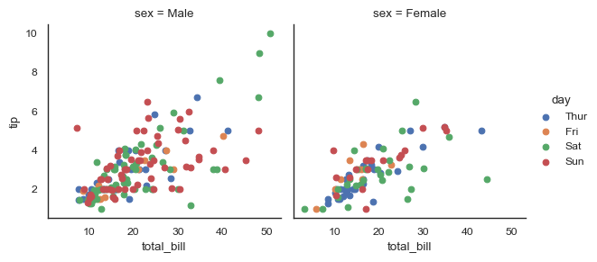

```python
plt.figure(figsize=(10,5))
graph=sns.FacetGrid(pf,col="sex",hue="day")

graph.map(plt.scatter,'total_bill','tip').add_legend()

plt.show()
```

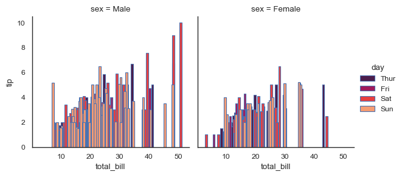

```python
graph=sns.FacetGrid(pf,col="sex",hue="day",palette="rocket")

graph.map(plt.bar,'total_bill','tip',edgecolor="b").add_legend()

plt.show()
```